# Статистический анализ данных (задание 4).

Работа с реальными данными.

Юлия Лукашкина, 417 группа

Известны значения приносимого молока на каждую корову в месяц в период с января 1962г. по декабрь 1975.

Задание: *Построить прогноз на 1/10 длины ряда с округлением до целого числа сезонных периодов.*

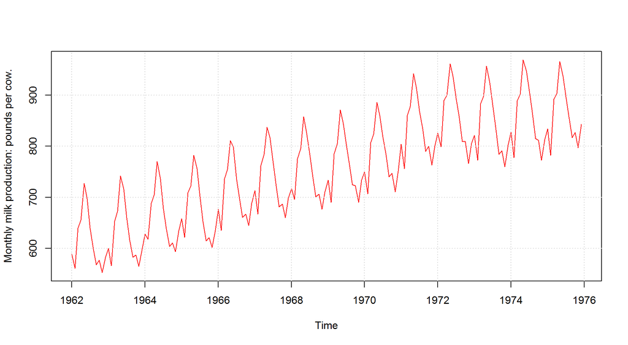

Попробуем поделить на число дней в месяце:

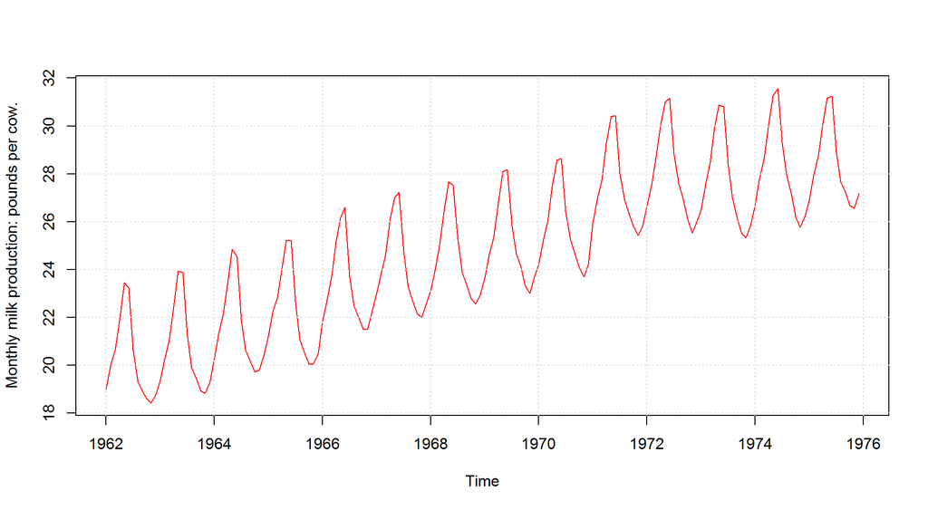

Ряд выглядит более стабильно, будем его исследовать. По внешнему виду ряда можно сделать следующие выводы:

- Выражена сезонность с периодом в 1 год.
- Максимум количества молока достигается примерно в конце первой половины каждого года (весна-лето).
- Существенных выбросов нет.
- Выражен линейный возрастающий тренд.
- Дисперсия постоянна.

Оптимальное преобразование Бокса-Кокса и результат его применения:

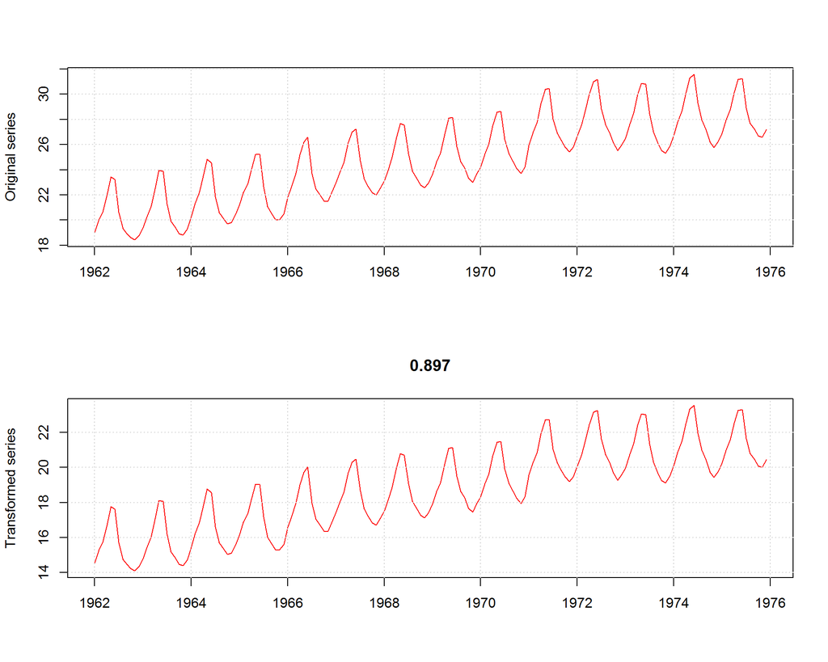

Применение оптимального преобразования Бокса-Кокса не вносит существенных изменений в поведение временного ряда, в дальнейшем работать будем только с исходными данными.

Проверим ряд на стационарность (p=0.01, критерий KPSS) — нестационарен. Ряд имеет выраженный сезонный профиль, проведем сезонное дифференцирование.

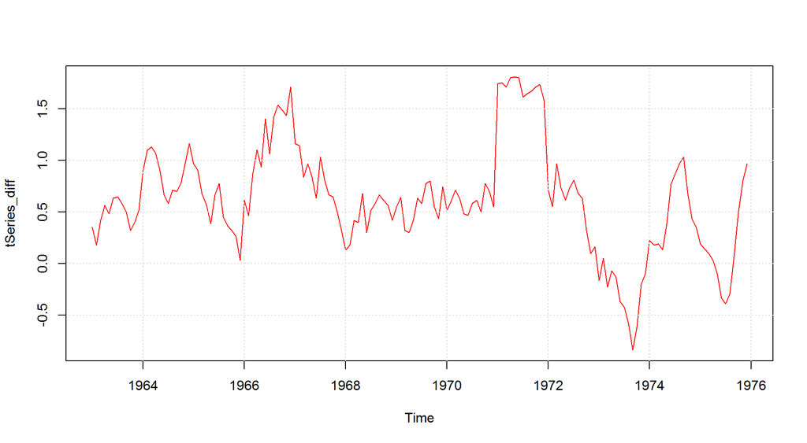

Получился ещё нестационарный ряд (p=0.019, критерий KPSS). Проведём ещё одно дифференцирование.

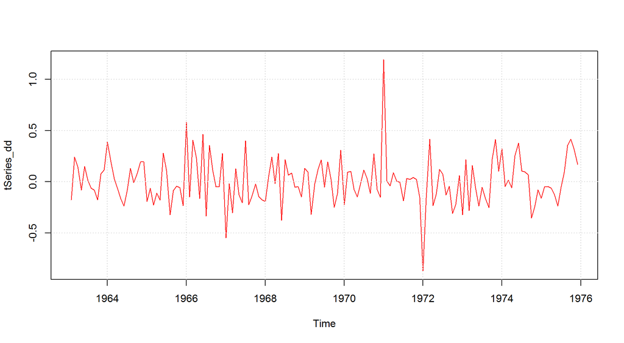

Получили стационарный ряд (p=0.1, критерий KPSS)!

## ARIMA

### Ручной подбор модели

Посмотрим на ACF и PACF полученного продифференцированного ряда:

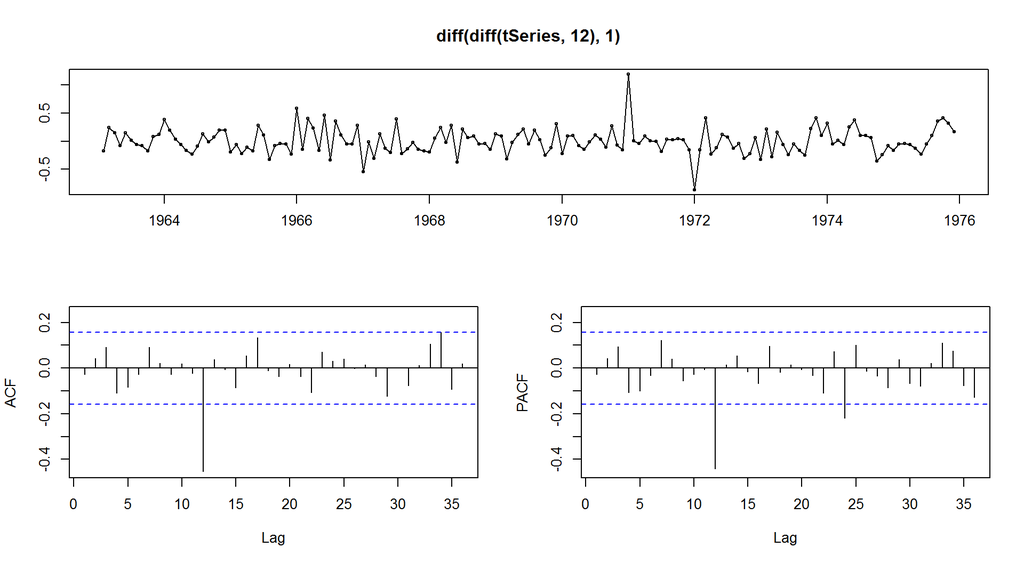

Значимый 12 лаг (связанный с сезоном). Будем искать модель в окрестности ARIMA(0,1,1)(0,1,1)$_{12}$.

| Модель | AICc |
| --- | --- |
| ARIMA(0,1,1)(0,1,1)$_{12}$ | -62.5362558 |
| ARIMA(1,1,1)(0,1,1)$_{12}$ | -60.4387987 |
| ARIMA(2,1,1)(0,1,1)$_{12}$ | -58.4102633 |
| ARIMA(3,1,1)(0,1,1)$_{12}$ | -58.8725023 |
| ARIMA(4,1,1)(0,1,1)$_{12}$ | -57.0027995 |
| ARIMA(0,1,1)(0,1,2)$_{12}$ | -60.4618125 |
| ARIMA(1,1,1)(0,1,2)$_{12}$ | -58.3350089 |
| ARIMA(2,1,1)(0,1,2)$_{12}$ | -56.2722448 |
| ARIMA(3,1,1)(0,1,2)$_{12}$ | -56.6789881 |
| ARIMA(2,1,1)(1,1,1)$_{12}$ | -56.2769579 |
| ARIMA(2,1,1)(1,1,0)$_{12}$ | -41.1373165 |
| ARIMA(2,1,1)(1,1,2)$_{12}$ | -54.1350651 |
| ARIMA(1,1,1)(1,1,1)$_{12}$ | -59.3964047 |
| ARIMA(3,1,1)(1,1,1)$_{12}$ | -56.1527901 |
| ARIMA(2,1,2)(1,1,1)$_{12}$ | -59.3176148 |

Наилучшая по AIC$_c$ модель — ARIMA(0,1,1)(0,1,1)$_{12}$. Исследуем остатки. Здесь и далее не будем рассматривать первые 12 значений остатков.

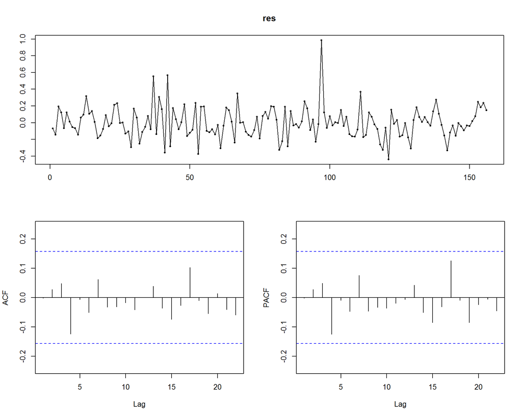

Достигаемые уровни значимости критерия Льюнга-Бокса для остатков:

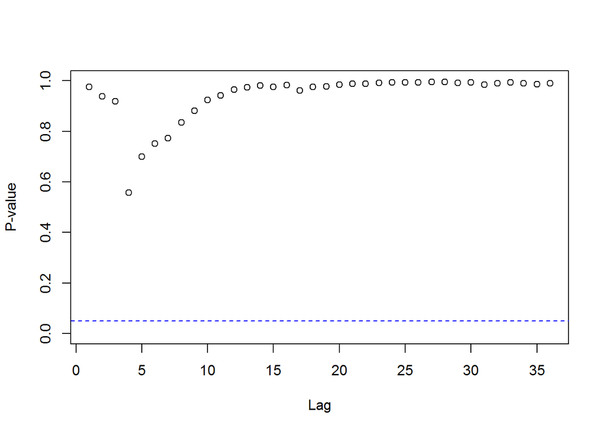

Q-Q plot и гистограмма для остатков:

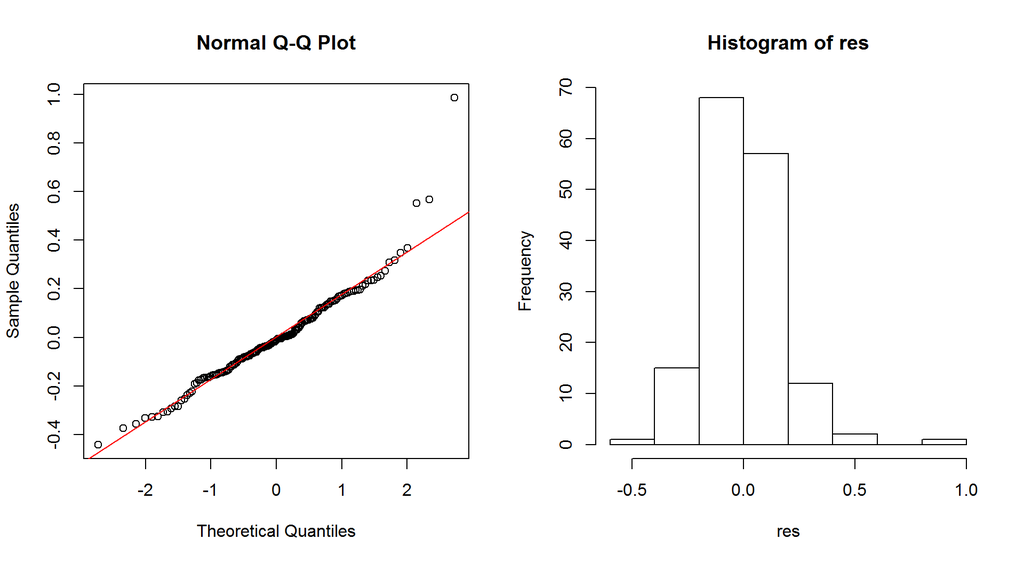

| Гипотеза | Критерий | Результат проверки | Достигаемый уровень значимости |
| --- | --- | --- | --- |
| Нормальность | Шапиро-Уилка | отвергается | 5.812969110^{-6} |
| Несмещённость | Уилкоксона | не отвергается | 0.6196748 |
| Стационарность | KPSS | не отвергается | 0.1 |
| Гомоскедастичность | Бройша-Пагана | не отвергается | 0.9701209 |

## AUTO ARIMA

Построим модель автоматически и сравним результат с построенной выше вручную моделью:

```
## Series: tSeries
## ARIMA(0,1,0)(1,1,1)[12]
##
## Coefficients:
##         sar1     sma1
##       0.0255  -0.7322
## s.e.  0.1215   0.1010
##
## sigma^2 estimated as 0.03552:  log likelihood=34.35
## AIC=-62.71   AICc=-62.55   BIC=-53.58
```

Построенная автоматически модель по AIC$_c$ не сильно отличается от построенной ранее. Посмотрим на остатки auto ARIMA.

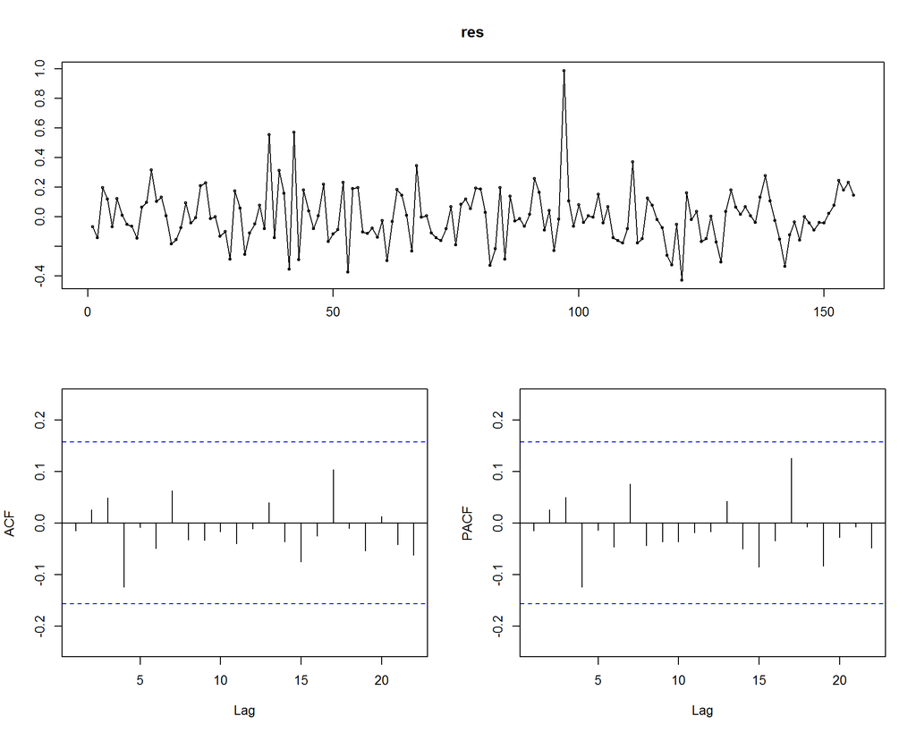

Достигаемые уровни значимости критерия Льюнга-Бокса для остатков:

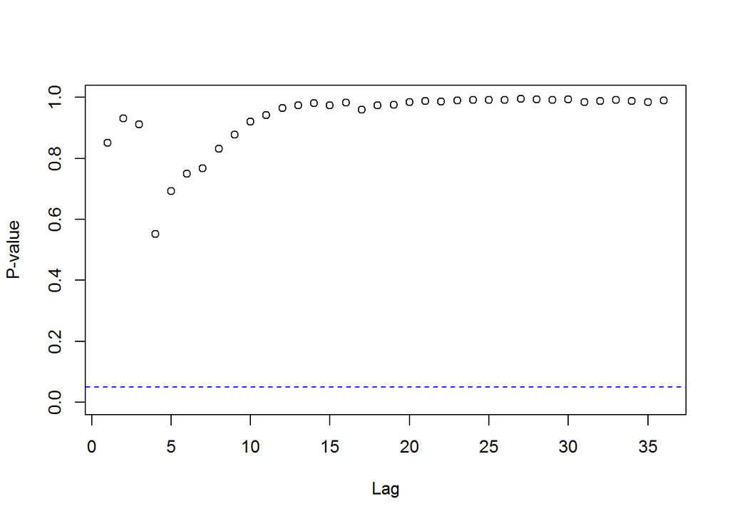

Q-Q plot и гистограмма для остатков:

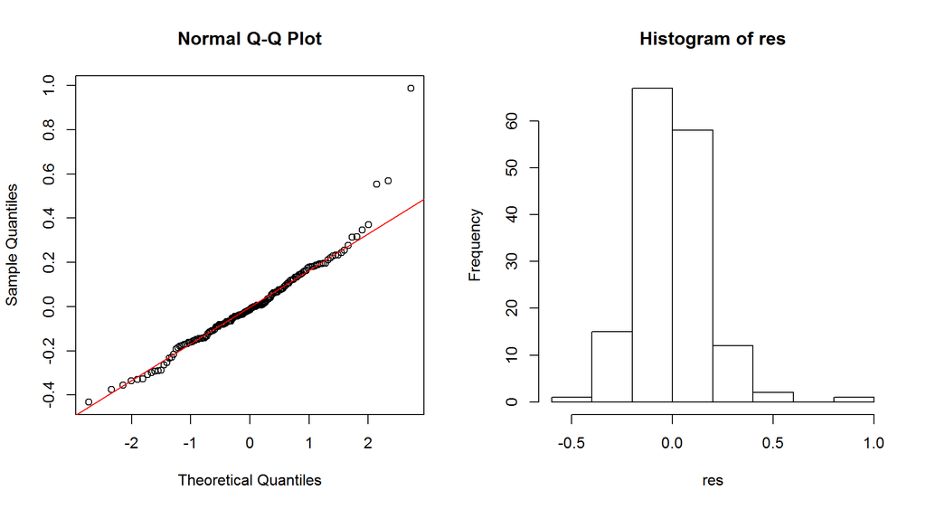

| Гипотеза | Критерий | Результат проверки | Достигаемый уровень значимости |
| --- | --- | --- | --- |
| Нормальность | Шапиро-Уилка | отвергается | 5.289316510^{-6} |
| Несмещённость | Уилкоксона | не отвергается | 0.6309523 |
| Стационарность | KPSS | не отвергается | 0.1 |
| Гомоскедастичность | Бройша-Пагана | не отвергается | 0.9591152 |

## Прогноз ETS

```
## ETS(A,Ad,A)
##
## Call:
##  ets(y = tSeries)
##
##   Smoothing parameters:
##     alpha = 0.9999
##     beta  = 0.0196
##     gamma = 1e-04
##     phi   = 0.98
##
##   Initial states:
##     l = 19.9555
##     b = 0.0822
##     s=-1.8523 -2.303 -2.0346 -1.3898 -0.7692 0.596
##            3.0978 3.1138 2.0159 0.6885 -0.1127 -1.0506
##
##   sigma:  0.1767
##
##      AIC     AICc      BIC
## 312.4711 316.5511 365.5785
```

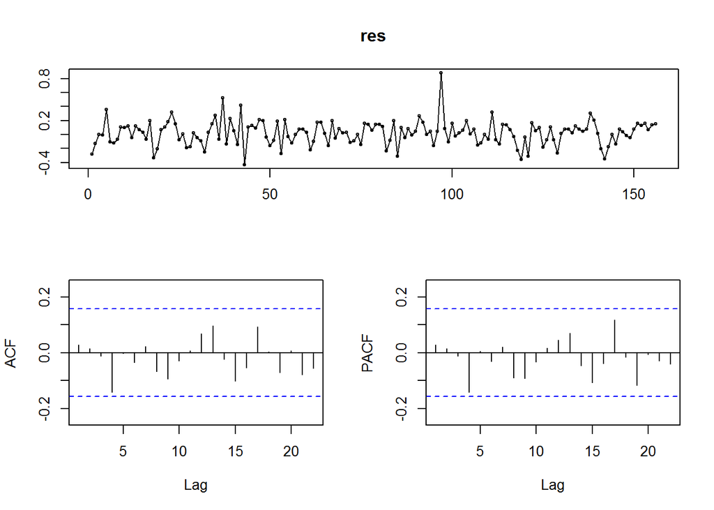

Достигаемые уровни значимости критерия Льюнга-Бокса для них:

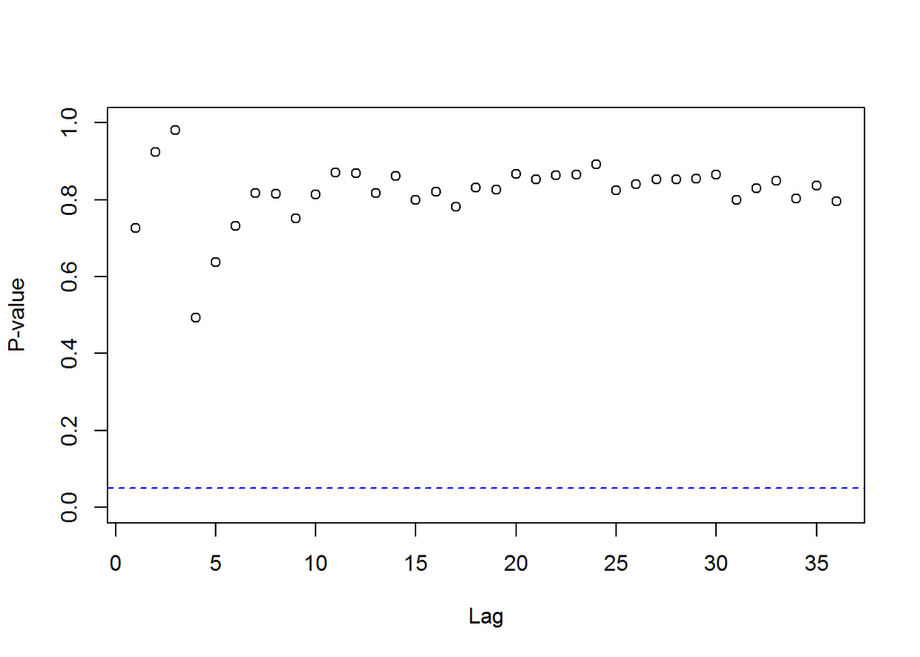

Q-Q plot и гистограмма для остатков:

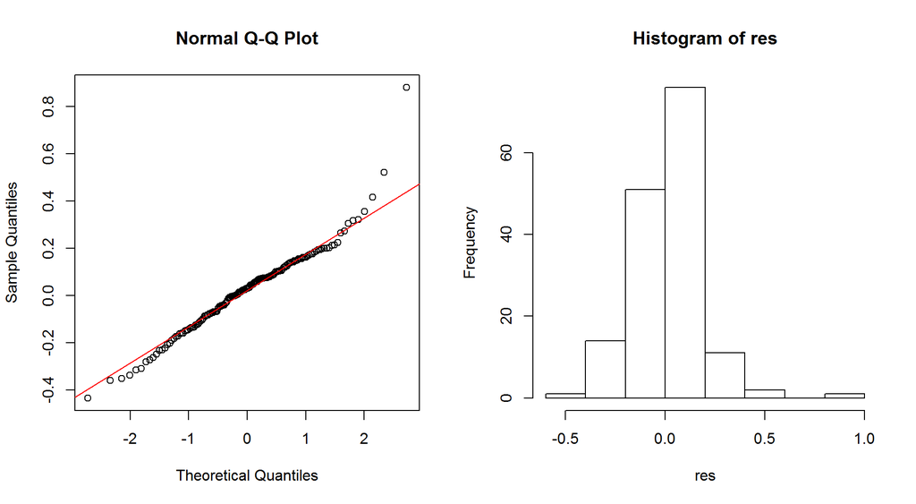

| Гипотеза | Критерий | Результат проверки | Достигаемый уровень значимости |
| --- | --- | --- | --- |
| Нормальность | Шапиро-Уилка | отвергается | 1.028139710^{-4} |
| Несмещённость | Уилкоксона | нe отвергается | 0.0915832 |
| Стационарность | KPSS | не отвергается | 0.1 |
| Гомоскедастичность | Бройша-Пагана | не отвергается | 0.6550984 |

## Сравнение моделей

Используем критерий Диболда-Мариано для попарного сравнения трех моделей: ARIMA auto, ARIMA и ETS.

```
##
##  Diebold-Mariano Test
##
## data:  res_etsres_arima
## DM = -1.7597, Forecast horizon = 1, Loss function power = 2,
## p-value = 0.08043
## alternative hypothesis: two.sided
```

```
##
##  Diebold-Mariano Test
##
## data:  res_etsres_auto
## DM = -1.7593, Forecast horizon = 1, Loss function power = 2,
## p-value = 0.0805
## alternative hypothesis: two.sided
```

```
##
##  Diebold-Mariano Test
##
## data:  res_autores_arima
## DM = -0.3408, Forecast horizon = 1, Loss function power = 2,
## p-value = 0.7337
## alternative hypothesis: two.sided
```

```
## [1] 0.1207569 0.1207569 0.7337340
```

Выберем модель по наименьшей ошибке на тестовой выборке. Последние 24 отсчета возьмем в качестве тестовой выборки. А остальные отсчеты в качестве тренировочной и перестроим на них полученные модели.

Настроив модели на обучающей выборке, построим предсказания на тестовой:

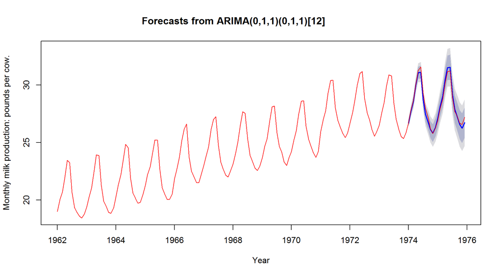

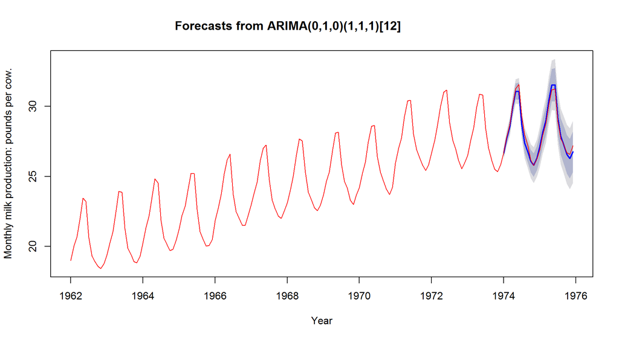

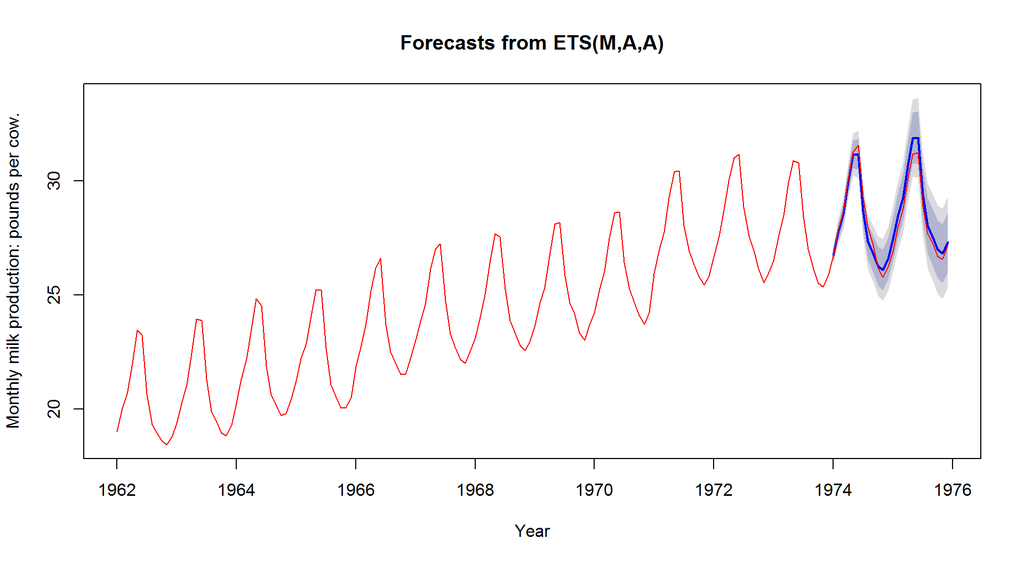

RMSE для ETS модели 0.4102744, ARIMA — 0.2848993, AUTO ARIMA — 0.2925164. Модель ARIMA, настроенная вручную лучше, прогноз будем строить с её помощью.

```
##          Point Forecast    Lo 80    Hi 80    Lo 95    Hi 95
## Jan 1976       27.98061 27.79366 28.17556 27.65281 28.32838
## Feb 1976       29.00807 28.70831 29.30195 28.54792 29.52879
## Mar 1976       29.88519 29.52302 30.25115 29.33057 30.52891
## Apr 1976       31.27583 30.84297 31.70592 30.63639 32.07449
## May 1976       32.36146 31.87290 32.85972 31.63779 33.26026
## Jun 1976       32.46316 31.92850 33.01901 31.65765 33.39326
## Jul 1976       30.11924 29.54005 30.70846 29.23287 31.10883
## Aug 1976       28.83919 28.22118 29.47317 27.91656 29.89297
## Sep 1976       28.21837 27.54722 28.89604 27.22868 29.32820
## Oct 1976       27.53345 26.83641 28.23112 26.47647 28.67938
## Nov 1976       27.25482 26.51597 28.00293 26.14172 28.49046
## Dec 1976       27.77856 26.99666 28.57939 26.63196 29.06222
## Jan 1977       28.56706 27.75002 29.42448 27.31739 29.93340
## Feb 1977       29.59452 28.73818 30.50101 28.29810 31.07000
## Mar 1977       30.47164 29.55863 31.44261 29.11093 31.99353
## Apr 1977       31.86228 30.90720 32.88000 30.39148 33.42198
## May 1977       32.94791 31.95451 33.99430 31.45710 34.59351
## Jun 1977       33.04961 32.00978 34.16056 31.51399 34.76103
## Jul 1977       30.70570 29.63325 31.84660 29.09353 32.47392
## Aug 1977       29.42564 28.29701 30.59439 27.73727 31.26592
## Sep 1977       28.80482 27.66210 30.00905 27.11363 30.73107
## Oct 1977       28.11990 26.93896 29.34547 26.33781 30.12530
## Nov 1977       27.84127 26.63784 29.11755 25.98286 29.86982
## Dec 1977       28.36501 27.12084 29.68100 26.49492 30.46156
```

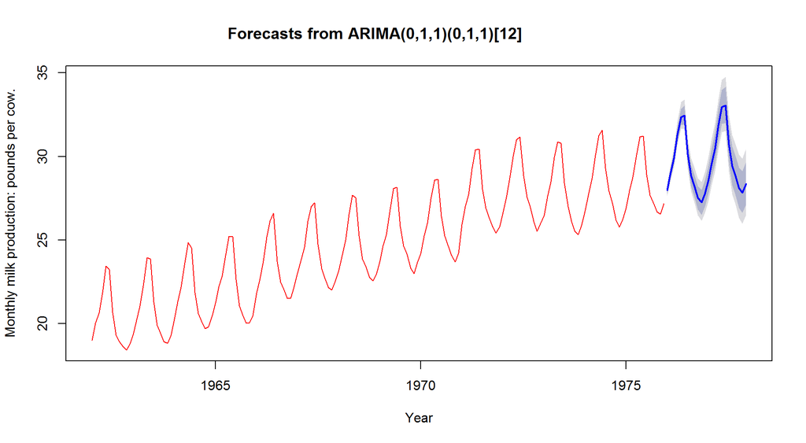